# Round numbers rating Survey 2: 234 participants

This notebook is supplementary material for paper submission. All the ID codes shown in the notebook (e.g., worker ID, HIT ID, assignment ID) have been anonymized.

## Set constants and define functions

```r
library(DT)
library(tidyverse)
library(lubridate)
library(knitr)
library(scales)
library(broom)
library(effectsize)
library(tidyr)
library(comprehenr)
library(dplyr)
library(lmerTest)
library(MuMIn)
library(glmnet)
library(sjPlot)
library(IRdisplay)
library(ggeffects)
knitr::opts_chunk$set(fig.width=15, fig.height=12)
```

```
#refugeeswelcome
```

First we read the data file and do some initial processing to:

- Replace the options `too-precise`, `looks-good`, `too-round` with the numbers 1, 2 and 3 respectively.
- Convert the data format from long to wide

```r
# set style
theme_set(theme_bw())

study_dates <- c("20210903", "20210907")
n_tasks <- 15
n_options <- 10
number_lengths <- c(4, 6, 7, 8, 10)

# helper function to display table in html format
display_table <- function(table) {
    table %>% kable("html") %>% as.character() %>% display_html()
}

read_mturk_data <- function(filename) {
    df <- read.csv(filename, stringsAsFactors=FALSE)
    # replace options with numeric values
    df[df == "too-precise"] <- 1
    df[df == "looks-good"] <- 2
    df[df == "too-round"] <- 3
    df
}

get_sentence_context <- function(sent) {
    if (grepl("the hospital group", sent)) {
        "Money"
    } else if (grepl("DNA evidence", sent)) {
        "People"
    } else {
        "Size"
    }
}

get_sentence_context <- Vectorize(get_sentence_context)

build_wide_data <- function(df) {
    # convert from long to wide format
    df <- df %>%
        filter(!variable %in% c("studyId", "workerId")) %>%
        pivot_wider(id_cols = c("hit_id", "assignment_id", "worker_id"), names_from = "variable", values_from = "value")
    # fill in missing columns to standardize the columns across studies
    # assume each task has at most 10 options
    for (task_num in 1:n_tasks) {
        for (option_num in 1:n_options) {
            number_col <- sprintf("task%d_option%d_number", task_num, option_num)
            rating_col <- sprintf("task%d_option%d_rating", task_num, option_num)
            if (!number_col %in% names(df)) {
                df <- df %>% mutate(!!number_col := NA, !!rating_col := NA)
            }
        }
    }
    # extract the context from the template sentences
    for (task_num in 1:n_tasks) {
        template_col <- sprintf("task%d_template", task_num)
        context_col <- sprintf("task%d_context", task_num)
        df <- df %>% mutate(!!context_col := get_sentence_context(df[[template_col]]))
    }
    # arrange the columns based on the task and option ordering
    task_option_cols <- to_vec(
        for (task_num in 1:n_tasks)
            for (option_num in 1:n_options)
                c(sprintf("task%d_option%d_number", task_num, option_num), sprintf("task%d_option%d_rating", task_num, option_num))
    )
    # select relevant columns for analyses
    start_time_cols = to_vec(for (task_num in 1:n_tasks) sprintf("task%d_start_time", task_num))
    context_cols = to_vec(for (task_num in 1:n_tasks) sprintf("task%d_context", task_num))
    given_num_cols = to_vec(for (task_num in 1:n_tasks) sprintf("task%d_given_number", task_num))
    df %>% select(
        "hit_id", "assignment_id", "worker_id", "finish_time", "submit_time",
        all_of(given_num_cols), all_of(task_option_cols), all_of(context_cols), all_of(start_time_cols)
    )
}

text_setting <- function(){
    theme(
        axis.title.y = element_text(size = 14),
        axis.text.y = element_text(size = 14),
        axis.text.x = element_text(size = 14),
        text = element_text(size = 14)
    )
}
```

## Load and clean data

```r
df_raw <- data.frame()
for (date in study_dates) {
    df_raw <- df_raw %>% rbind(read_mturk_data(sprintf("data/anon_rating_mturk_data_%s.csv", date)))
}
df_wide <- build_wide_data(df_raw)

nrow(df_wide)
```

234

```r
df_wide %>%
    rename(WorkerId = worker_id) %>%
    select(WorkerId) %>%
    mutate(`UPDATE-taken-round-numbers-rating-2021` = 1) %>%
    write_csv("data/mturk_quals_toupload.csv")
```

For each participant and each task, we check whether their answers to that task are sensible (i.e., following the order of "too-precise", "looks-good", "too-round")

```r
check_sensible_options <- function(row) {
    row <- row %>% as.numeric() %>% na.omit()
    sorted_row <- row %>% sort(decreasing = FALSE)
    as.numeric(all(row == sorted_row))
}

for (task_num in 1:n_tasks) {
    sensible_col <- sprintf("task%d_sensible", task_num)
    matcher <- sprintf("task%d_option[1-9]0*_rating", task_num)
    df_wide <- df_wide %>% mutate(!!sensible_col := df_wide %>% select(matches(matcher)) %>% apply(1, check_sensible_options))
}

df_wide <- df_wide %>% mutate(n_sensibles = df_wide %>% select(matches("sensible")) %>% rowSums())
```

We plot the number of sensible tasks for each participant:

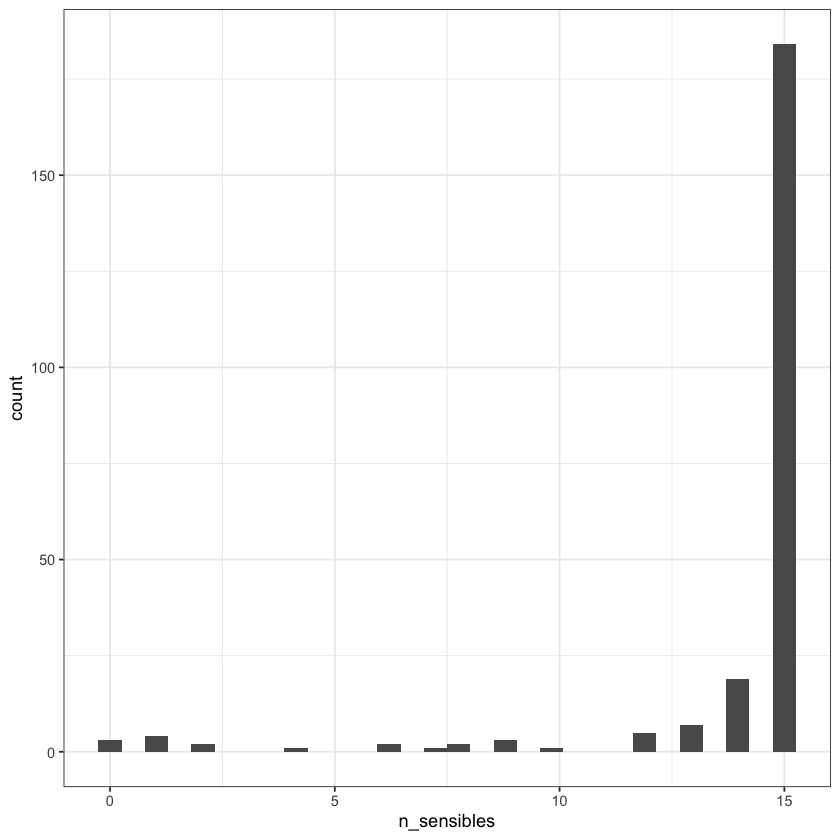

```r
df_wide %>% ggplot(aes(x = n_sensibles)) + geom_histogram()
```

From this point, we will remove participants who have fewer than 12 sensible task responses.

```r
removed_participants <- df_wide %>% filter(n_sensibles < 12) %>% select(worker_id)
df_raw <- df_raw %>% anti_join(removed_participants)
df_wide <- df_wide %>% anti_join(removed_participants)

print(sprintf("Final sample size: %d", df_wide %>% nrow()))
```

```
[1] "Final sample size: 215"
```

We also build a long representation of the data, where each row corresponds to a single rating in a task.

```r
pretty_number_to_float <- function(s) {
    multiplier <- 1
    if (grepl('million$', s)) {
        multiplier <- 1e6
    }
    if (grepl('billion$', s)) {
        multiplier <- 1e9
    }
    s <- gsub('[,a-z ]', '', s)
    as.numeric(s) * multiplier
}

pretty_number_to_float <- Vectorize(pretty_number_to_float)

build_long_data <- function(ratings_from_mturk) {
    ratings_with_split_variable <- ratings_from_mturk %>%
        separate(variable, into = c('task_index', 'option_index', 'number_or_rating'), sep = '_')

    task_option_rating <- ratings_with_split_variable %>%
          filter(grepl('option', option_index)) %>%
          mutate(task_index = as.numeric(gsub('task', '', task_index)),
                 option_index = as.numeric(gsub('option', '', option_index))) %>%
          pivot_wider(names_from = number_or_rating, values_from = value)

    template_given <- ratings_with_split_variable %>%
      filter(option_index %in% c("template", "given")) %>%
      mutate(task_index = as.numeric(gsub('task', '', task_index))) %>%
      select(-number_or_rating) %>%
      pivot_wider(names_from = option_index, values_from = value) %>%
      rename(full_given_number = given)

    # count number of non-zero leading digits
    # h/t to https://stackoverflow.com/a/49024636
    task_option_rating %>%
        inner_join(template_given) %>%
        mutate(
          number = pretty_number_to_float(number),
          full_given_number = pretty_number_to_float(full_given_number),
          full_length = ceiling(log10(full_given_number)),
          prefix = gsub('0*$', '', sprintf('%.0f', number)),
          prefix_length = nchar(prefix)
        )
}

df_long <- build_long_data(df_raw)
```

Now we incorporate the sensible task checking into this long dataset and exclude all the tasks whose response are not sensible.

```r
df_sensible <- df_wide %>%
    pivot_longer(cols = task1_sensible:task15_sensible, names_pattern = "task([0-9]+)_sensible", names_to = "task_index", values_to = "is_sensible") %>%
    mutate(task_index = as.numeric(task_index)) %>%
    select(hit_id, assignment_id, worker_id, task_index, is_sensible)

df_long <- df_long %>% inner_join(df_sensible) %>% filter(is_sensible == 1)
```

```r
sum(df_wide$n_sensibles)
```

3177

## "Looks Good" responses

### Percentage of "Looks Good" ratings at each rounding threshold

The following graph breaks down by number length and context.

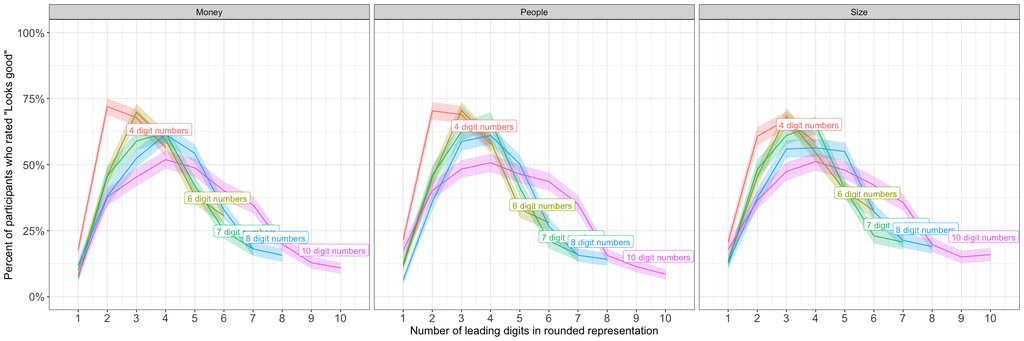

```r
plot_data <- df_long %>%
    mutate(
        full_length = as.factor(full_length),
        context = get_sentence_context(template)) %>%
    group_by(prefix_length, full_length, context) %>%
    summarize(count = n(),
            frac_looks_good = mean(rating == 2),
            se = sqrt(frac_looks_good * (1 - frac_looks_good) / n()))

label_data <- plot_data %>%
    group_by(full_length, context) %>%
    filter(prefix_length == full_length) %>%
    ungroup(full_length) %>%
    mutate(label = sprintf('%s digit numbers', full_length),
         full_length = as.integer(as.character(full_length)))

options(repr.plot.width = 18, repr.plot.height = 6)
ggplot(plot_data, aes(x = prefix_length, y = frac_looks_good)) +
    geom_ribbon(aes(ymin = frac_looks_good - se, ymax = frac_looks_good + se, fill = full_length), alpha = 0.25) +
    geom_line(aes(color = full_length)) +
    geom_label(data = label_data, aes(x = full_length, y = frac_looks_good, label = label, color = as.factor(full_length)), hjust = 0.6, vjust = -1) +
    scale_y_continuous(label = percent, lim = c(0,1)) +
    scale_x_continuous(breaks = 1:10, lim = c(0.5, 10.5)) +
    text_setting() +
    labs(x = 'Number of leading digits in rounded representation',
       y = 'Percent of participants who rated "Looks good"') +
    facet_wrap(~ context, nrow = 1) +
    theme(legend.position = "none")
ggsave(filename = 'figures/looks_good_linegraphs_nodecimal.png', width = 18, height = 6)
```

### Switching threshold from "Too precise" to "Looks good" and from "Looks good" to "Too round"

```r
find_prefix_length_last_occurrence <- function(task_ratings, prefix_lengths, rating_value = 2) {
    compare = which(task_ratings == rating_value)
    if (length(compare) > 0) {
        prefix_lengths[tail(compare, n = 1)]
    } else {
        NA
    }
}

df_switch <- df_long %>%
    group_by(hit_id, assignment_id, worker_id, task_index) %>%
    summarize(
        last_looks_good_prefix_length = find_prefix_length_last_occurrence(rating, prefix_length, 2),
        last_too_round_prefix_length = find_prefix_length_last_occurrence(rating, prefix_length, 3),
        full_length = min(full_length)
    ) %>%
    filter(!is.na(last_looks_good_prefix_length))
```

[output not shown]

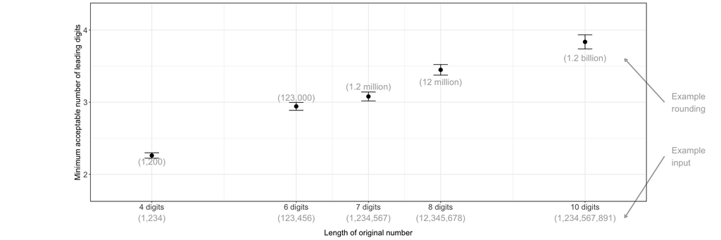

```r
plot_data <- df_switch %>%
    filter(!is.na(last_looks_good_prefix_length)) %>%
    group_by(full_length) %>% summarize(
        mu = mean(last_looks_good_prefix_length),
        sd = sqrt(var(last_looks_good_prefix_length)),
        se = sd / sqrt(n())
    )

labels <- tribble(
    ~full_length, ~example_precise, ~example_round, ~offset,
    4, "1,234", "(1,200)", -1,
    NA, NA, NA, NA, #"12,345", NA, NA,
    6, "123,456", "(123,000)", 1,
    7, "1,234,567", "(1.2 million)", 1,
    8, "12,345,678", "(12 million)", -1,
    NA, NA, NA, NA, #"123,456,789", NA, NA,
    10, "1,234,567,891", "(1.2 billion)", -1
    ) %>%
    left_join(plot_data) %>%
    mutate(xlabel = sprintf('%s digits', ifelse(is.na(full_length), "", as.character(full_length))),
           xexample = ifelse(is.na(example_precise), "", sprintf('(%s)', example_precise)),
           y = mu + 2.25*offset*se)

ggplot(plot_data, aes(x = full_length, y = mu, ymax = mu + se, ymin = mu - se)) +
    geom_point(size = 3) +
    geom_errorbar(width = .2) +
    geom_text(data = labels, aes(x = full_length, y = y, label = example_round), size = 5.5, color = "darkgrey") +
    geom_text(data = labels, aes(x = full_length, label = xexample), y = 1.4, size = 5.5, color = "darkgrey") +
    scale_x_continuous(breaks = labels$full_length, labels = labels$xlabel) +
    scale_y_continuous(breaks = 1:4) +
    annotate("text", x = 11.2, y = 3, label = "Example\nrounding", size = 5.5, color = "darkgrey", hjust = 0, fontface = 1) +
    annotate("segment", x = 11.1, xend = 10.55, y = 3, yend = 3.6, color = "darkgrey",
             arrow = arrow(ends = "last", length = unit(.2,"cm")), size = 1.0) +
    annotate("text", x = 11.2, y = 2.25, label = "Example\ninput", size = 5.5, color = "darkgrey", hjust = 0, fontface = 1) +
    annotate("segment", x = 11.1, xend = 10.55, y = 2.25, yend = 1.4, color = "darkgrey",
             arrow = arrow(ends = "last", length = unit(.2,"cm")), size = 1.0) +
    coord_equal(xlim = c(3.5, 10.5), ylim = c(1.75, 4.25), clip = "off") +
    text_setting() +
    labs(x = '\n\nLength of original number', y = 'Minimum acceptable number of leading digits')
```

Below we also plot the full distribution of the ratings at each full number length group.

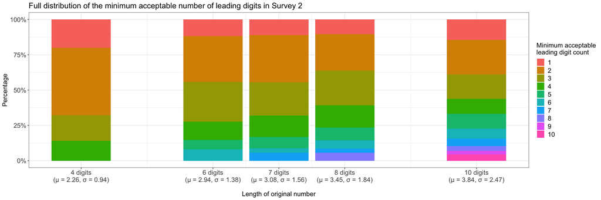

```r
construct_label_distplot <- function(xlabel, mu_value, sd_value) {
    sprintf("%s\n(\U03BC = %.2f, \U03C3 = %.2f)\n", xlabel, mu_value, sd_value)
}

construct_label_distplot <- Vectorize(construct_label_distplot)

plot_data <- plot_data %>%
    left_join(labels) %>%
    mutate(distplot_xlabel = construct_label_distplot(xlabel, mu, sd))

options(warn = -1)
df_switch %>%
    group_by(full_length, last_looks_good_prefix_length) %>%
    count(last_looks_good_prefix_length) %>%
    group_by(full_length) %>%
    mutate(percent = n / sum(n)) %>%
    arrange(full_length, last_looks_good_prefix_length) %>%
    mutate(last_looks_good_prefix_length = as.factor(last_looks_good_prefix_length)) %>%
    ggplot(aes(x = full_length, y = percent, fill = last_looks_good_prefix_length)) +
    geom_bar(position = "stack", stat = "identity") +
    text_setting() +
    theme(legend.text = element_text(size = 14)) +
    scale_x_continuous(breaks = plot_data$full_length, labels = plot_data$distplot_xlabel) +
    scale_y_continuous(label = percent, lim = c(0, 1)) +
    scale_fill_discrete(name = "Minimum acceptable\nleading digit count") +
    labs(
        x = 'Length of original number',
        y = 'Percentage',
        title = "Full distribution of the minimum acceptable number of leading digits in Survey 2"
    )

ggsave("figures/survey2_full_rating_distribution.png", width = 18, height = 6)
options(warn = 0)
```

```r
df_model <- df_long %>%
    mutate(context = get_sentence_context(template)) %>%
    group_by(hit_id, assignment_id, worker_id, task_index) %>%
    summarize(
        last_looks_good_prefix_length = find_prefix_length_last_occurrence(rating, prefix_length),
        full_given_number = min(full_given_number),
        full_length = min(full_length),
        context = first(context)
    ) %>%
    filter(!is.na(last_looks_good_prefix_length))
```

### Linear models

We want to see which features can help predict people's rounding preference, operationalized as `min_acceptable_prefix_length`, the minimum number of significant digits to be rated as "Looks good" in a task.

We will also use the Worker ID as the random effect, since the data points are not independent, i.e., we are doing mixed effect models. We evaluate the models using (1) the MSE, and (2) the $R^2$, in particular the values returned by the function `r.squaredGLMM` from the [MuMIn package](https://cran.r-project.org/web/packages/MuMIn/MuMIn.pdf):

- Marginal $R^2 = \frac{\sigma_f^2}{\sigma_f^2 + \sigma_\alpha^2 + \sigma_\epsilon^2}$ represents the variance explained by the fixed effect.
- Conditional $R^2 = \frac{\sigma_f^2 + \sigma_\alpha^2}{\sigma_f^2 + \sigma_\alpha^2 + \sigma_\epsilon^2}$ represents the variance explained by the entire model (including both the fixed and random effect).

```r
df_linear <- df_model %>%
    ungroup(worker_id) %>%
    mutate(
        worker_id = as.factor(worker_id),
        context = as.factor(context)
    ) %>%
    rename(min_acceptable_prefix_length = last_looks_good_prefix_length)
```

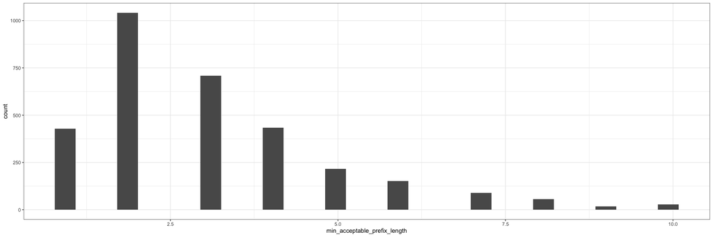

```r
df_linear %>% ggplot(aes(x = min_acceptable_prefix_length)) + geom_histogram()
```

Our baseline model is:

$M_{0}: \text{Prefix} \sim (1 \mid \text{Worker})$

```r
model <- lmer(
    min_acceptable_prefix_length ~ (1|worker_id),
    data = df_linear
)
print(r.squaredGLMM(model))
print(modelr::mse(model, df_linear))
summary(model)
```

```
     R2m       R2c
[1,]   0 0.4968776
[1] 1.524814
```

```
Linear mixed model fit by REML. t-tests use Satterthwaite's method [
lmerModLmerTest]
Formula: min_acceptable_prefix_length ~ (1 | worker_id)
   Data: df_linear

REML criterion at convergence: 11133.2

Scaled residuals:
    Min      1Q  Median      3Q     Max
-3.2377 -0.5650 -0.0558  0.3866  4.9755

Random effects:
 Groups    Name        Variance Std.Dev.
 worker_id (Intercept) 1.608    1.268
 Residual              1.628    1.276
Number of obs: 3170, groups:  worker_id, 215

Fixed effects:
             Estimate Std. Error        df t value Pr(>|t|)
(Intercept)   3.12534    0.08941 213.74870   34.96   <2e-16 ***
---
Signif. codes:  0 ‘***’ 0.001 ‘**’ 0.01 ‘*’ 0.05 ‘.’ 0.1 ‘ ’ 1
```

Our full model is:

$M_1: \text{Prefix} \sim \text{Full Length} + \text{Context} + (1 \mid \text{Worker})$

```r
model <- lmer(
    min_acceptable_prefix_length ~  full_length + context + (1|worker_id),
    data = df_linear
)
print(r.squaredGLMM(model))
print(modelr::mse(model, df_linear))
summary(model)
```

```
            R2m       R2c
[1,] 0.08656508 0.5903676
[1] 1.241821
```

```
Linear mixed model fit by REML. t-tests use Satterthwaite's method [
lmerModLmerTest]
Formula: min_acceptable_prefix_length ~ full_length + context + (1 | worker_id)
   Data: df_linear

REML criterion at convergence: 10545.7

Scaled residuals:
    Min      1Q  Median      3Q     Max
-4.0752 -0.5622 -0.0160  0.5181  4.7998

Random effects:
 Groups    Name        Variance Std.Dev.
 worker_id (Intercept) 1.634    1.278
 Residual              1.328    1.153
Number of obs: 3170, groups:  worker_id, 215

Fixed effects:
                Estimate Std. Error         df t value Pr(>|t|)
(Intercept)      1.29271    0.11830  625.84483  10.928   <2e-16 ***
full_length      0.26392    0.01023 2952.22781  25.802   <2e-16 ***
contextPeople   -0.06022    0.05019 2952.26731  -1.200    0.230
contextSize      0.01946    0.05020 2952.18382   0.388    0.698
---
Signif. codes:  0 ‘***’ 0.001 ‘**’ 0.01 ‘*’ 0.05 ‘.’ 0.1 ‘ ’ 1

Correlation of Fixed Effects:
            (Intr) fll_ln cntxtP
full_length -0.605
contextPepl -0.215  0.004
contextSize -0.213  0.000  0.501
```

```r
summary(model)
```

```
Linear mixed model fit by REML. t-tests use Satterthwaite's method [
lmerModLmerTest]
Formula: min_acceptable_prefix_length ~ full_length + context + (1 | worker_id)
   Data: df_linear

REML criterion at convergence: 10545.7

Scaled residuals:
    Min      1Q  Median      3Q     Max
-4.0752 -0.5622 -0.0160  0.5181  4.7998

Random effects:
 Groups    Name        Variance Std.Dev.
 worker_id (Intercept) 1.634    1.278
 Residual              1.328    1.153
Number of obs: 3170, groups:  worker_id, 215

Fixed effects:
                Estimate Std. Error         df t value Pr(>|t|)
(Intercept)      1.29271    0.11830  625.84483  10.928   <2e-16 ***
full_length      0.26392    0.01023 2952.22781  25.802   <2e-16 ***
contextPeople   -0.06022    0.05019 2952.26731  -1.200    0.230
contextSize      0.01946    0.05020 2952.18382   0.388    0.698
---
Signif. codes:  0 ‘***’ 0.001 ‘**’ 0.01 ‘*’ 0.05 ‘.’ 0.1 ‘ ’ 1

Correlation of Fixed Effects:
            (Intr) fll_ln cntxtP
full_length -0.605
contextPepl -0.215  0.004
contextSize -0.213  0.000  0.501
```

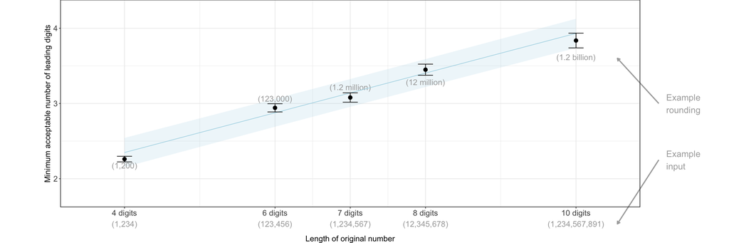

```r
plot_data <- df_switch %>%
    filter(!is.na(last_looks_good_prefix_length)) %>%
    group_by(full_length) %>% summarize(
        mu = mean(last_looks_good_prefix_length),
        sd = sqrt(var(last_looks_good_prefix_length)),
        se = sd / sqrt(n())
    )

pred_data <- ggpredict(model, terms = "full_length")

ggplot(plot_data, aes(x = full_length, y = mu)) +
    geom_ribbon(data = pred_data, aes(x = x, y = predicted, ymax = conf.high, ymin = conf.low), alpha = 0.2, fill = "lightblue") +
    geom_text(data = labels, aes(x = full_length, y = y, label = example_round), size = 5, color = "darkgrey") +
    geom_text(data = labels, aes(x = full_length, label = xexample), y = 1.4, size = 5, color = "darkgrey") +
    geom_line(data = pred_data, aes(x = x, y = predicted), color = "lightblue") +
    geom_errorbar(aes(ymax = mu + se, ymin = mu - se), width = .2) +
    geom_point(size = 3) +
    scale_x_continuous(breaks = labels$full_length, labels = labels$xlabel) +
    scale_y_continuous(breaks = 1:4) +
    annotate("text", x = 11.2, y = 3, label = "Example\nrounding", size = 5.5, color = "darkgrey", hjust = 0, fontface = 1) +
    annotate("segment", x = 11.1, xend = 10.55, y = 3, yend = 3.6, color = "darkgrey",
             arrow = arrow(ends = "last", length = unit(.2,"cm")), size = 1.0) +
    annotate("text", x = 11.2, y = 2.25, label = "Example\ninput", size = 5.5, color = "darkgrey", hjust = 0, fontface = 1) +
    annotate("segment", x = 11.1, xend = 10.55, y = 2.25, yend = 1.4, color = "darkgrey",
             arrow = arrow(ends = "last", length = unit(.2,"cm")), size = 1.0) +
    coord_equal(xlim = c(3.5, 10.5), ylim = c(1.75, 4.25), clip = "off") +
    text_setting() +
    labs(x = '\n\nLength of original number', y = 'Minimum acceptable number of leading digits') +
    theme(plot.margin = margin(t = 0, r = 7.5, b = 0, l = 2, unit = "lines"))
ggsave(filename = 'figures/min_acceptable_precision_level_dist_nodecimal_with_examples.png', width = 15, height = 10)
```

**Take-aways**:

1. The worker ID plays an important role in predicting how much rounding is acceptable, i,e., rounding preference is highly individual.
2. Even within person, the given's number full length still have some predictive power.

## Additional Analyses

### Is 5 special as a last leading digit?

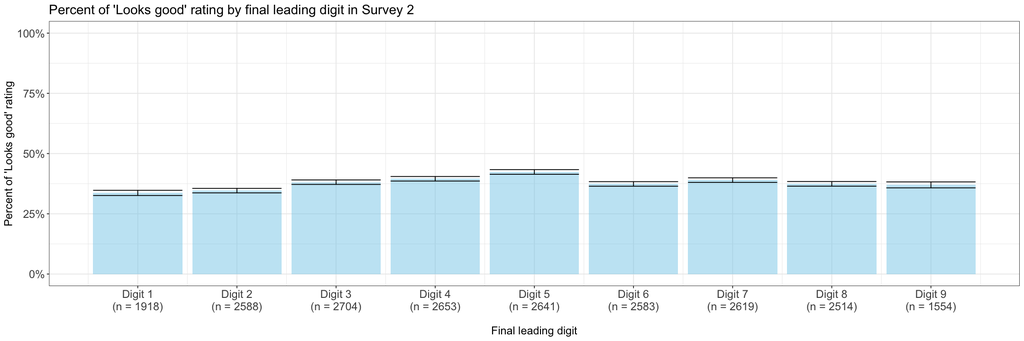

```r
plot_data <- df_long %>%
    mutate(last_leading_digit = substr(prefix, prefix_length, prefix_length) %>% as.integer()) %>%
    group_by(last_leading_digit) %>%
    summarize(
        count = n(),
        frac = sum(rating == 2) / count,
        se = sqrt(frac * (1 - frac) / count),
        lower = frac - se,
        upper = frac + se
    ) %>%
    mutate(label = mapply(sprintf, "Digit %s\n(n = %d)\n", last_leading_digit, count))

plot_data %>%
    ggplot(aes(x = last_leading_digit, y = frac)) +
    geom_bar(stat = "identity", fill = "skyblue", alpha = 0.5) +
    geom_errorbar(aes(x = last_leading_digit, ymin = lower, ymax = upper)) +
    scale_x_continuous(breaks = plot_data$last_leading_digit, labels = plot_data$label) +
    scale_y_continuous(label = percent, lim = c(0,1)) +
    text_setting() +
    labs(x = "Final leading digit", y = "Percent of 'Looks good' rating", title = "Percent of 'Looks good' rating by final leading digit in Survey 2") +

ggsave(filename = "figures/survey2_pct_looks_good_by_final_digit.png", width = 15, height = 10)
```